# CKMR simulation results: 100% biennial female breeders

```
## Of the 7200 parameter estimates from these simulations, 8 instances failed to converge at Rhat > 1.01
```

## Background info

One hundred different populations were simulated where 100% of females in the population bred biennially.

Each population was sampled at four different sampling intensities corresponding to 0.5, 1, 1.5, and 2 percent of the juvenile population each year over four consecutive years of sampling. Samples were either targeted to the young-of-year (YOY) portion of the population only, or included juveniles of all age classes. A pairwise comparisons matrix that included all possible positive and negative comparisons was used as input to a CKMR model that either a) assumed no prior information for breeding schedule (psi) *or* survival (phi), or b) assumed the breeding schedule was known without error (i.e. fixed to the truth) *and* included a tight prior on survival dnorm(mean = truth, sd = 0.02).

## Figure 1: Accuracy of abundance estimates depends on sampling scheme and prior demographic information

**Sampling scheme:** Red and blue reflect sampling schemes that target YOY only; green and purple reflect sampling schemes where the entire juvenile population (ages 0-11) were available for sampling.  
**Prior information:** Red and green results come from a model that assumed no prior information for psi or survival; blue and purpose results come from a model that assumed psi was known without error and gave a tight prior to survival.  
**Main takeaways:** This figure shows results for the lowest and highest sample schemes employed only (i.e. 0.5% and 2% of the juvenile population). When all age classes are sampled, the HPDI is slightly less likely to capture the truth, suggesting that the model may converge on inaccurate values in some instances. However, the density plots show that the median of the posteriors for the same scenarios do tend to be centered on 0.

With diffuse priors on psi and survival (red and green), there is a difference in the potential for the HPDI to capture the truth, with targeted sampling (red) performing better than sampling across age classes. Regardless of sampling scheme, when using a diffuse prior on survival and psi, the posterior medians for abundance estimates have a tendency to get pulled upward, similar to survival (Fig 2), though this effect is reduced when all age classes are sampled relative to targeted sampling of YOY.

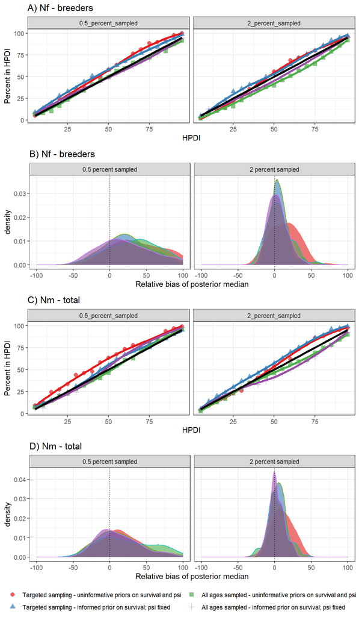

## Figure 2: Accuracy of survival estimates depends on sampling scheme and prior demographic information

**Sampling scheme:** Red and blue reflect sampling schemes that target YOY only; green and purple reflect sampling schemes where the entire juvenile population (ages 0-11) were available for sampling.  
**Prior information:** Red and green results come from a model that assumed no prior information for psi or survival (diffuse priors); blue and purpose results come from a model that assumed psi was known without error and gave a tight prior to survival.  
**Main takeaways:** When priors are diffuse (red and green), survival estimates have a tendency to get pulled upward. This tendency is amplified when sampling is targeted to YOY (red), likely because there are fewer age gaps represented in the data as well as fewer half-siblings available to inform survival estimates.

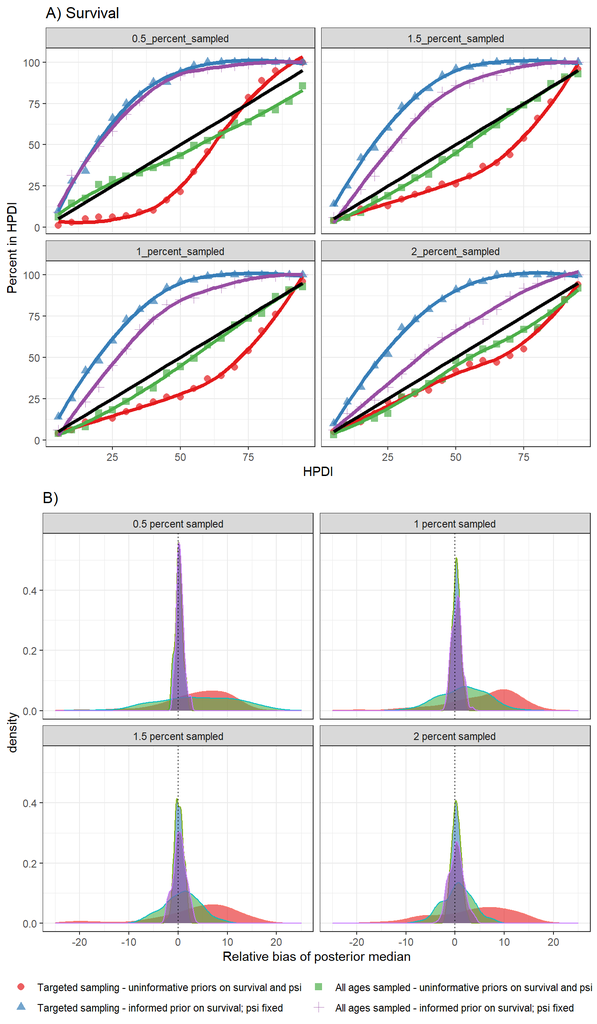

## Figure 3: Observed numbers of maternal - but not paternal - half-siblings depends on sampling scheme when females breed biennially.

**A and B:** Number of HSPs detected based on sampling scheme. **A)** For females that breed intermittently, more HSPs are found when sampling across juvenile age classes. When sampling is limited to YOY over four years of sampling, and females breed every other year, there are only two potential comparisons that would be expected to yield HSPs (cohorts 1 & 3; cohorts 2 & 4). When sampling across age classes, there are more cohorts available to yield HSPs. **B)** For males that breed annually, there is no difference in the number of HSPs detected based on sampling scheme. Note that for both males and females, the lowest sampling intensity results in fewer than 25 HSPs, which is half the recommended target of 50 for a reasonable CV. This is why results at this sampling intensity are so varied.  
**C and D:** Relative bias of abundance estimate by the percent difference between observed and expected HSPs. Here, we see that as the observed number of HSPs deviates from expectations, results become more biased, as expected. Interestingly, we see an exponential rise in bias in the positive direction at the lowest sampling intensity, but this trend is not apparent in the negative direction. **C)** notice that when priors are diffuse, there remains a slight residual positive bias across sampling intensities when observed and expected HSPs match (i.e. x axis = 0) **D)** However, that bias disappears when survival and psi are given informed priors (except at the lowest sampling intensity).

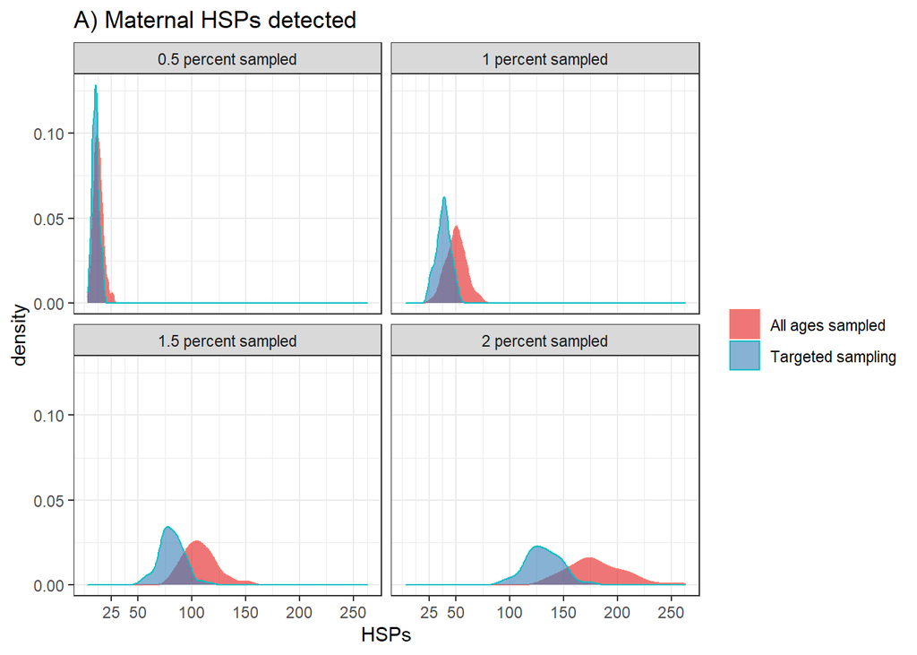

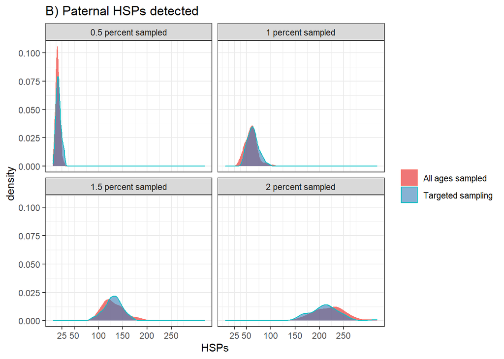

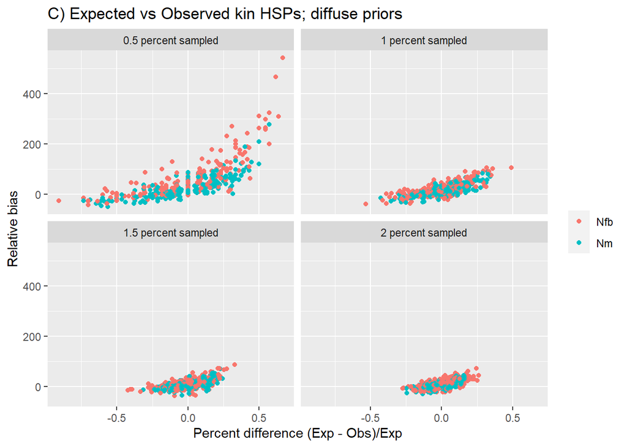

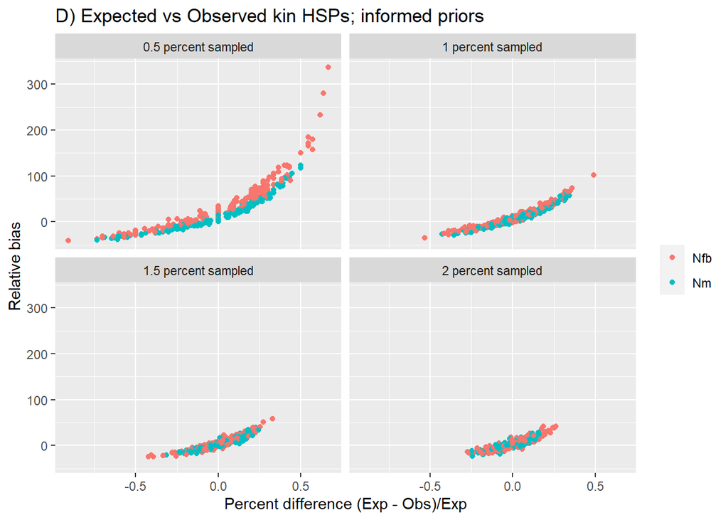